Andrew Koren & Krish Patel

# 2 - Quick Review

2 The signal appears damped (time constant is greater than 25sec)

# 3 - Spring constant via equilibrium position

1 For mass in equilibrium:

$$\sum F = F_g + F_s = mg - k\Delta x =0$$

This gives us $\Delta x = \frac{g}{k} m$

2 Spring constant depends on the spring, not the mass

3 To determine the value of $k$, we'll make a plot of mass vs equilibrium position. Since force of the spring depends on equilibrium position, increasing mass will lead to increased equilibrium position. We measure for 3 mass configurations, not including the mass of the spring. The slope will be $\frac{g}{k}$, which can be used to calculate $k$ by finding slope and plugging in gravitational acceleration

4 See table

| mass (g) | dm (g) | x0 (cm) | x0 (m) | dx0(m) |
| --- | --- | --- | --- | --- |
| 100.4 | 0.2 | 18.15 | 0.1815 | 0.005 |
| 150.6 | 0.3 | 27.2 | 0.272 | 0.005 |
| 200.6 | 0.4 | 35.1 | 0.351 | 0.005 |

5 Curve.fit

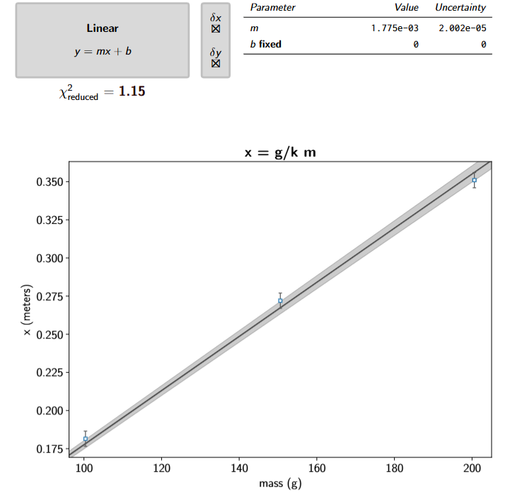

6 $\omega_0^2 = \frac{k}{m}$. From the table we have

$$ \sqrt{\frac{5.526}{.1004}} = 7.42 \\ \sqrt{\frac{5.526}{.1506}} = 6.06 \\ \sqrt{\frac{5.526}{.2006}} = 5.24 \\ $$

```python
m = [.1004, .1506, .2006]
print([((5.526)/(mass))**(1/2) for mass in m])
```

```
[7.4188840560727325, 6.057493466082605, 5.248557699618185]
```

# 4 - Period measurement

1 Use $\omega = 2\pi f = \sqrt{\frac{k}{m}} $ $$ \left(\frac{2\pi}{T} \right)^2 = \frac{k}{m} \\ k = \frac{4\pi^2}{T^2}m $$

2 We use the same mass configurations from before

```python
import pandas as pd
import numpy as np

df = pd.DataFrame({
    "mass (g)": [100.4, 150.6, 200.6],
    "f1 (Hz)": [1.18, 0.943, 0.826],
    "f2 (Hz)": [1.14, 0.943, 0.82],
    "f3 (Hz)": [1.14, 0.943, 0.813],
})

def avg_freq(row):
    m, *f = row
    return np.average(f)

df['average_f (Hz)'] = df.apply(avg_freq, axis=1)
df['T_avg (s)'] = 1/df["average_f (Hz)"]
df['k'] = 4*np.pi**2/(df["T_avg (s)"]**2)*df['mass (g)']
print(df)
print(np.mean(df['k']), np.std(df['k'])/len(df))
```

```
   mass (g)  f1 (Hz)  f2 (Hz)  f3 (Hz)  average_f (Hz)  T_avg (s)            k
0     100.4    1.180    1.140    1.140        1.153333   0.867052  5272.336705
1     150.6    0.943    0.943    0.943        0.943000   1.060445  5286.985192
2     200.6    0.826    0.820    0.813        0.819667   1.220008  5320.656396
5293.326098049565 6.743191039630499
```

Part 2: Automatic measurement

1, 2 completed

3 1000 measurements / 10 seconds = 100 measurements / sec $\rightarrow dt = .01$

4 curve.fit

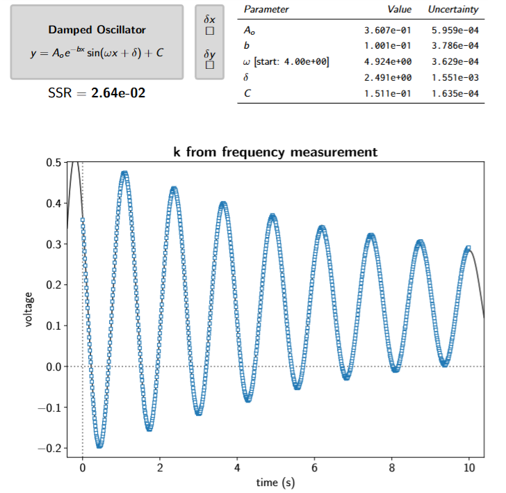

$$ \omega = 4.924 \pm 0.0004 = \sqrt{k/m} \\ m = 200.6 \pm 0.1 \\ k = \omega^2 m = 4.924^2(200.6) = 4863 \pm \sqrt{(2\omega m \delta m)^2 + \omega^2 \delta m} = 4863 \pm 197 \\ = 4900 \pm 200 $$

```python
omega = 4.924
domega = .0004
mass = 200.6
dmass = 0.1

print(omega**2*mass)
((2*omega*mass*dmass)**2 + (omega**2 * dmass)**2)**(1/2)
```

```
4863.702665600001
```

```
197.56575807895666
```

[output not shown]

# 5 - Damped

1 We used masses $154.3g$ and $204.8g$.

Here are our plots:

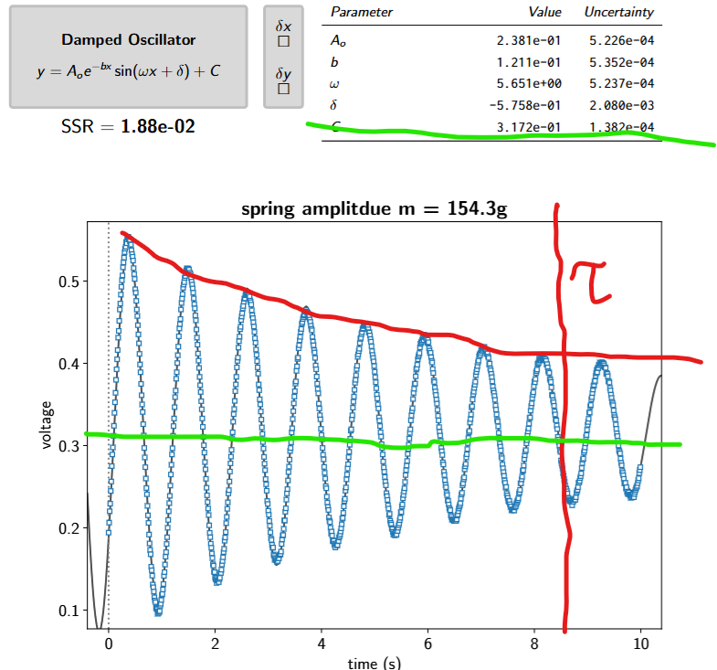

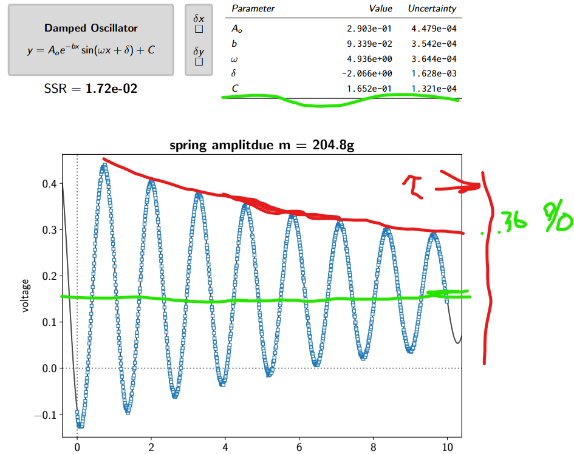

Time constant is inverse of damping rate, which is represented as $b$ in the curve fit $\tau=\frac{1}{b}$. Note that $b$ has a different value in each plot.

$$ \tau_1 = \frac{1}{.121}=8.26s \\ \tau_2 = \frac{1}{0.0934} = 10.71s $$

4 This was the final lab of the year. We used many concepts we've learned throughout, such as error propogation and desiging experiments based on equations that model the physical situation. We compared multiple methods to find spring coefficient, and also learned about damped oscillation. We also used a digital measurement tool to make a more accurate curve fit (digital = many data points).

Overall, the toughest part was converting from experimental data and uncertainty to finding the target constants, but this is something we've done all year.